# pm566-midterm

Author

Stella Zhou

## 1. Introduction

On May 11, 2023, the federal Public Health Emergency (PHE) for COVID-19 had officially been expired under section 319 of the Public Health Service (PHS) Act. Over the last two years, The COVID-19 pandemic, which swept across the globe in early 2020, has posed an unprecedented challenge to public health systems, economies, and daily life. As the world grappled with the profound impact of the virus, the development and deployment of effective vaccines emerged as a critical pillar in the fight against this novel coronavirus. Within the United States, each state faced unique challenges and opportunities in administering vaccines, reflecting variations in population density, healthcare infrastructure, and sociodemographic factors. California, as one of the most populous states in the nation, has been a focal point of the pandemic response. With urban centers, rural areas, and diverse communities, California’s experience with COVID-19 and its vaccination efforts provide a rich case study for understanding the dynamics of vaccine distribution, uptake, and public health outcomes.

The question of interest in this project is twofold: How have COVID-19 vaccination rates varied by county in California since the initial implementation, and what factors are associated with these vaccination rates? This inquiry is not only relevant for evaluating the effectiveness of vaccination campaigns but also for identifying disparities and potential areas for improvement in public health strategies. Analyzing vaccination rates across California’s counties can shed light on the impact of demographic, socioeconomic, and healthcare-related variables on vaccine coverage.

In this data analysis, county-level data is explored to understand the overall trend of cases, deaths, and vaccination rates over the two years, the extent to which communities have been reached, and the determinants of their vaccination rates.

## 2. Methods

### Downloading Data

The data sets used in this project are obtained from California Health and Human Services. [`vac`](https://data.chhs.ca.gov/dataset/covid-19-post-vaccination-infection-data) refers to COVID-19 Post-Vaccination Infection Data (ARCHIVED) and [`death`](https://data.chhs.ca.gov/dataset/covid-19-time-series-metrics-by-county-and-state) refers to COVID-19 Cases Deaths Tests Data Dictionary (ARCHIVED). [`covid_income`](https://data.ca.gov/dataset/income-limits-by-county) refers to Income Limits by County.

```r
library(data.table)
library(dplyr)
library(dtplyr)
library(tidyverse)
library(lubridate)
vac <- read.csv("vac.csv")
death <- read.csv("death.csv")
covid_income <- fread("income.csv", select = c("county", "AMI"))
```

### Data Wrangling & EDA

```r
dim(death)
dim(vac)
dim(covid_income)
str(death)
str(vac)
str(covid_income)
```

```r
death$date <- as.Date(death$date, "%Y-%m-%d")
vac$administered_date <- as.Date(vac$administered_date,"%Y-%m-%d")

death <-
  death %>% mutate(county = area)

vac <-
  vac %>% mutate(date = administered_date)

vac1 <- vac
vac1$county <-replace(vac$county, vac$county=="All CA Counties","California")
```

The datasets are merged by date and county and NAs are filtered. The data is further subseted into `covid_county` and `covid_CA` for further analysis. New variables are created for further analysis:

1. `cum_dose_pp`: cumulative total dose divided by the population in each county, in other words, average number of doses per person.
2. `percent_vacc`: cumulative fully vaccinated divided by population, in other words, vaccination rate.

```r
covid_merge = merge(x = death,y = vac1, by= c("date","county"), all=TRUE)
covid_merge <- covid_merge %>%
  filter(!is.na(county))
```

```r
covid_county <-
  covid_merge %>%
  filter (county != "All CA and Non-CA Counties" &
            county != "All CA Counties" &
            county != "California" &
            county !="Out of state"&
            county !="Outside California"&
            county !="Unknown")

covid_county <- covid_county %>%
  mutate(cum_dose_pp = (cumulative_total_doses/population),
         percent_vacc = (cumulative_fully_vaccinated/population))
```

```r
covid_CA <-
  covid_merge %>%
  filter (county == "California")
```

Since the cumulative value of all variables are the highest on the last day of entry, I subseted `covid_county1` to be the data set corresponding to the last day of entry, in order to obtain summary statistics. Furthermore, the county level median income dataset is merged in `covid_county1`.

```r
covid_county <- data.table(covid_county)
covid_county1 <- covid_county[!is.na(percent_vacc)]
covid_county1 <-
  covid_county1 %>%
  filter(date==as.Date("2023-05-09"))

covid_county1= merge(x=covid_county1, y=covid_income, by=c("county"),all=TRUE)
```

## Preliminary Results

### Part 1. Summary tables

```r
covid_county %>%
  group_by(county) %>%
  filter(date >= as.Date("2020-02-01")) %>%
  summarise(Cases_mean = mean(cases,na.rm = TRUE),
            Cases_max = max(cases,na.rm = TRUE),
            Cases_sd = sd(cases,na.rm = TRUE),
            Deaths_mean = mean(deaths,na.rm = TRUE),
            Deaths_max = max(deaths,na.rm = TRUE),
            Deaths_sd = sd(deaths,na.rm = TRUE),
            Population = mean(population,na.rm = TRUE),
            Dose_mean = mean(total_doses,na.rm = TRUE),
            Doses_max = max(total_doses,na.rm = TRUE),
            Doses_sd = sd(total_doses,na.rm = TRUE)) %>%
  knitr::kable(col.names = c("County",
                             "Mean Cases",
                             "Max Cases",
                             "SD Cases",
                             "Mean Deaths",
                             "Max Deaths",
                             "SD Deaths",
                             "Population",
                             "Mean Doses",
                             "Max Doses",
                             "SD Doses"), digits = 1, "pipe",
               caption = "Table 1. Summary Statistics for Counties in California (2020-02-01 to 2023-05-09)")
```

Table 1. Summary Statistics for Counties in California (2020-02-01 to 2023-05-09)

| County | Mean Cases | Max Cases | SD Cases | Mean Deaths | Max Deaths | SD Deaths | Population | Mean Doses | Max Doses | SD Doses |
| --- | --- | --- | --- | --- | --- | --- | --- | --- | --- | --- |
| Alameda | 323.1 | 6137 | 585.4 | 1.9 | 20 | 2.6 | 1685886 | 4062.9 | 26189 | 5157.8 |
| Alpine | 0.1 | 6 | 0.5 | 0.0 | 0 | 0.0 | 1117 | 1.6 | 87 | 6.3 |
| Amador | 9.0 | 286 | 17.7 | 0.1 | 2 | 0.3 | 38531 | 59.4 | 769 | 99.9 |
| Butte | 35.2 | 396 | 51.4 | 0.4 | 5 | 0.8 | 217769 | 307.2 | 3423 | 475.6 |
| Calaveras | 7.6 | 131 | 13.4 | 0.1 | 2 | 0.4 | 44289 | 65.6 | 902 | 109.0 |
| Colusa | 3.4 | 44 | 5.4 | 0.0 | 2 | 0.1 | 22593 | 30.1 | 503 | 57.6 |
| Contra Costa | 232.1 | 3587 | 387.2 | 1.3 | 15 | 1.9 | 1160099 | 2767.5 | 18800 | 3631.0 |
| Del Norte | 6.7 | 77 | 11.3 | 0.1 | 5 | 0.3 | 27558 | 35.2 | 502 | 58.5 |
| El Dorado | 29.3 | 538 | 47.3 | 0.2 | 5 | 0.6 | 193098 | 330.3 | 3230 | 454.8 |
| Fresno | 249.2 | 3850 | 403.5 | 2.5 | 23 | 3.6 | 1032227 | 1554.5 | 12708 | 2181.1 |
| Glenn | 4.9 | 62 | 7.7 | 0.0 | 2 | 0.2 | 29348 | 37.6 | 676 | 71.1 |
| Humboldt | 19.7 | 247 | 28.9 | 0.1 | 4 | 0.4 | 134098 | 254.4 | 2309 | 360.0 |
| Imperial | 59.9 | 837 | 92.2 | 0.8 | 10 | 1.6 | 191649 | 475.6 | 5505 | 689.4 |
| Inyo | 4.0 | 103 | 8.5 | 0.1 | 2 | 0.2 | 18453 | 31.6 | 597 | 57.9 |
| Kern | 194.4 | 2569 | 297.9 | 2.1 | 18 | 2.9 | 927251 | 1166.5 | 10540 | 1626.0 |
| Kings | 53.0 | 1135 | 87.6 | 0.4 | 5 | 0.8 | 156444 | 167.3 | 1701 | 245.9 |
| Lake | 11.5 | 170 | 17.0 | 0.1 | 4 | 0.4 | 64871 | 91.9 | 1086 | 145.1 |
| Lassen | 8.6 | 191 | 20.7 | 0.1 | 3 | 0.3 | 30065 | 21.1 | 1035 | 50.5 |
| Los Angeles | 2946.3 | 60879 | 6041.7 | 30.2 | 306 | 48.0 | 10257557 | 19763.6 | 140066 | 26211.9 |
| Madera | 39.2 | 655 | 60.2 | 0.3 | 6 | 0.7 | 160089 | 214.6 | 2054 | 311.1 |
| Marin | 41.9 | 595 | 63.6 | 0.3 | 5 | 0.6 | 260800 | 726.6 | 5857 | 961.2 |
| Mariposa | 2.8 | 50 | 4.9 | 0.0 | 2 | 0.2 | 17795 | 24.2 | 534 | 53.1 |
| Mendocino | 14.3 | 223 | 21.7 | 0.1 | 3 | 0.4 | 88439 | 165.5 | 2257 | 285.1 |
| Merced | 65.3 | 940 | 99.9 | 0.8 | 11 | 1.2 | 287420 | 373.6 | 3851 | 554.9 |
| Modoc | 0.8 | 16 | 1.6 | 0.0 | 2 | 0.1 | 9475 | 9.3 | 207 | 24.0 |
| Mono | 2.8 | 149 | 7.3 | 0.0 | 1 | 0.1 | 13961 | 23.7 | 726 | 64.2 |
| Monterey | 82.8 | 1121 | 144.2 | 0.7 | 15 | 1.6 | 448732 | 840.0 | 10352 | 1197.5 |
| Napa | 29.3 | 541 | 52.4 | 0.1 | 4 | 0.4 | 139652 | 318.4 | 3081 | 465.3 |
| Nevada | 17.1 | 256 | 27.4 | 0.1 | 4 | 0.4 | 98710 | 182.3 | 1604 | 263.1 |
| Orange | 602.9 | 11208 | 1165.6 | 6.8 | 72 | 10.7 | 3228519 | 6249.0 | 43571 | 8332.7 |
| Placer | 68.9 | 997 | 104.0 | 0.6 | 8 | 1.1 | 400434 | 758.7 | 4913 | 990.8 |
| Plumas | 3.2 | 46 | 5.5 | 0.0 | 1 | 0.1 | 18997 | 27.5 | 697 | 61.2 |
| Riverside | 619.9 | 8997 | 1086.5 | 5.7 | 61 | 9.2 | 2468145 | 3761.8 | 28061 | 5074.1 |
| Sacramento | 315.4 | 5176 | 516.3 | 3.0 | 21 | 3.5 | 1567975 | 2916.7 | 18855 | 3627.5 |
| San Benito | 14.9 | 195 | 24.6 | 0.1 | 3 | 0.3 | 64022 | 119.9 | 1079 | 169.8 |
| San Bernardino | 599.1 | 9174 | 1105.4 | 6.8 | 75 | 11.5 | 2217398 | 3118.3 | 22493 | 4185.1 |
| San Diego | 832.6 | 16329 | 1626.0 | 4.9 | 58 | 8.0 | 3370418 | 6892.0 | 44580 | 8510.3 |
| San Francisco | 167.3 | 2954 | 287.8 | 1.0 | 10 | 1.5 | 892280 | 2324.6 | 17237 | 3064.6 |
| San Joaquin | 177.7 | 3100 | 303.8 | 2.0 | 20 | 3.0 | 782545 | 1277.1 | 9692 | 1673.3 |
| San Luis Obispo | 56.1 | 828 | 101.1 | 0.5 | 7 | 1.0 | 278862 | 523.4 | 4612 | 766.2 |
| San Mateo | 155.8 | 2718 | 286.2 | 0.6 | 12 | 1.4 | 778001 | 2005.1 | 13540 | 2528.8 |
| Santa Barbara | 94.8 | 1685 | 172.5 | 0.6 | 12 | 1.3 | 456373 | 847.9 | 8513 | 1214.9 |
| Santa Clara | 404.5 | 6379 | 703.3 | 2.3 | 32 | 3.9 | 1967585 | 4816.8 | 44758 | 6682.2 |
| Santa Cruz | 58.1 | 1304 | 109.7 | 0.2 | 7 | 0.7 | 273999 | 615.3 | 4968 | 834.3 |
| Shasta | 30.7 | 282 | 41.5 | 0.5 | 7 | 1.0 | 177925 | 217.6 | 3127 | 325.8 |
| Sierra | 0.3 | 7 | 0.7 | 0.0 | 1 | 0.1 | 3115 | 4.1 | 176 | 13.1 |
| Siskiyou | 4.6 | 48 | 6.4 | 0.1 | 2 | 0.3 | 43956 | 57.8 | 1650 | 114.8 |
| Solano | 96.6 | 1404 | 153.7 | 0.4 | 6 | 0.8 | 444255 | 854.7 | 7050 | 1147.3 |
| Sonoma | 96.4 | 1710 | 175.3 | 0.5 | 6 | 0.9 | 496668 | 1145.9 | 8112 | 1563.7 |
| Stanislaus | 122.7 | 1378 | 168.1 | 1.5 | 12 | 2.1 | 562303 | 803.8 | 6193 | 1111.3 |
| Sutter | 21.8 | 288 | 31.6 | 0.2 | 5 | 0.6 | 105747 | 141.0 | 1675 | 213.4 |
| Tehama | 12.2 | 127 | 17.5 | 0.2 | 3 | 0.5 | 65885 | 70.6 | 789 | 109.8 |
| Trinity | 1.2 | 17 | 2.3 | 0.0 | 2 | 0.1 | 13354 | 16.0 | 472 | 37.2 |
| Tulare | 108.5 | 1754 | 172.4 | 1.3 | 13 | 2.1 | 484423 | 616.6 | 5409 | 885.3 |
| Tuolumne | 14.3 | 293 | 24.9 | 0.2 | 4 | 0.5 | 52351 | 77.3 | 1370 | 149.5 |
| Ventura | 186.3 | 3167 | 351.3 | 1.4 | 20 | 2.7 | 852747 | 1648.7 | 12193 | 2272.4 |
| Yolo | 42.4 | 682 | 71.8 | 0.4 | 5 | 0.7 | 223612 | 455.8 | 3906 | 617.3 |
| Yuba | 16.9 | 248 | 24.6 | 0.1 | 3 | 0.4 | 79290 | 95.0 | 814 | 128.9 |

Table 1. provides summary statistics for cases, deaths, and daily doses for counties in California. (Note that the minimum values were all 0 therefore not included in the summary.) Based on the table, counties with higher population have more cases, deaths, and daily doses in general, which is expected due to the nature of infectious diseases. One limitation to this analysis is that the population for each county had remained the same over the 2 years in the data set.

```r
covid_top5 <- covid_county1[rank(-percent_vacc) <=5]
covid_top5 <- covid_top5[order(-percent_vacc)]
covid_top5[,list(date, county,population,cumulative_cases,cumulative_deaths,cumulative_total_doses,percent_vacc,AMI)]
```

```
         date        county population cumulative_cases cumulative_deaths
1: 2023-05-09      Imperial     191649            71545               982
2: 2023-05-09         Marin     260800            49972               317
3: 2023-05-09     San Mateo     778001           186050               742
4: 2023-05-09   Santa Clara    1967585           482934              2770
5: 2023-05-09 San Francisco     892280           199735              1211
   cumulative_total_doses percent_vacc    AMI
1:                 545286    0.9469551  80300
2:                 811487    0.8955982 166000
3:                2262832    0.8631506 166000
4:                5476285    0.8568748 168500
5:                2616570    0.8497389 166000
```

```r
covid_bot5 <- covid_county1[rank(-percent_vacc) >=54]
covid_bot5 <- covid_bot5[order(percent_vacc)]
covid_bot5[,list(date, county,population,cumulative_cases,cumulative_deaths,cumulative_total_doses,percent_vacc,AMI)]
```

```
         date  county population cumulative_cases cumulative_deaths
1: 2023-05-09  Lassen      30065            10294                64
2: 2023-05-09   Modoc       9475              982                 9
3: 2023-05-09  Tehama      65885            14566               236
4: 2023-05-09 Trinity      13354             1481                23
5: 2023-05-09   Kings     156444            63267               486
   cumulative_total_doses percent_vacc   AMI
1:                  24355    0.2988857 80300
2:                  10695    0.3956728 80300
3:                  81526    0.4367155 80300
4:                  18386    0.4525236 80300
5:                 194017    0.4564317 80300
```

Table 2 and 3 provides detailed statistics on the 5 counties with the highest vaccination rates and the lowest rates. The top five counties are Imperial, Marin, San Mateo, Santa Clara, and San Fransisco. The lowest are Lassen, Modoc, Tehama, Trinity, and Kings. Figure 1. below shows the fully vaccinated percent for all counties in detail. This brings out the question of what factors are associated with the difference in vaccination rates.

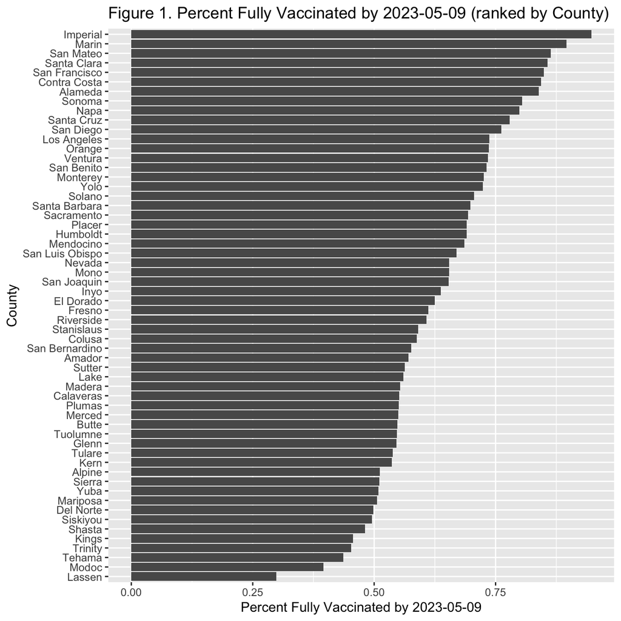

```r
covid_county1 %>%
  ggplot(aes(y = reorder(county, percent_vacc), x = percent_vacc)) +
  geom_bar(stat = "identity") +
  labs(y = "County", x = "Percent Fully Vaccinated by 2023-05-09") +
  theme(legend.position = "none") +
  ggtitle("Figure 1. Percent Fully Vaccinated by 2023-05-09 (ranked by County)")
```

### Part 2. Visualization of cumulative dose over time by counties

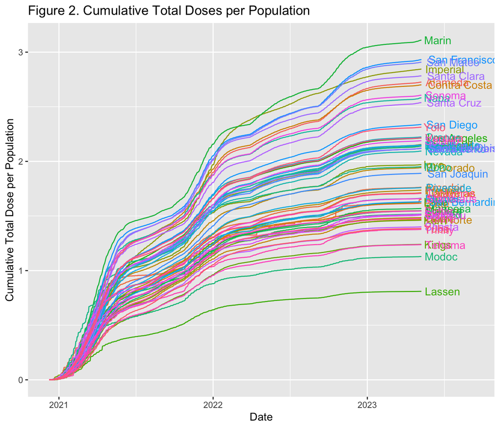

```r
library(ggplot2)
covid_county %>%
  ggplot(mapping=aes(x = date, y = cum_dose_pp, color = county, na.rm = TRUE)) +
  geom_line() + geom_text(data=subset(covid_county, date=="2023-05-09"), aes(label=county),hjust=-.1) +
  scale_x_date(name="Date", limits = as.Date(c("2020-12-09", "2023-09-09"))) +
  scale_y_continuous(name="Cumulative Total Dose per Population", breaks = seq(0,3,by=1)) +
  theme(legend.position="none") +
  ggtitle("Figure 2. Cumulative Total Doses per Population ")
```

Figure 2. shows the cumulative dose (standardized by population) over time by counties. We can observe that there are three visible inclines in cumulative doses, and approached plateau around April 2021, January 2022, and December 2022. The three sections probably corresponded to the initial outbreak for the alpha variant, the following Delta variant in July 2021 and Omicron BA.1 variant in December 2021, and Omicron BA.2, XBB variants in summer 2022. We can observe similar rankings of cumulative total dose, by counties, to the results in Figure 1.

### Part 3. Time series comparison of cases, deaths, and total doses in California

```r
p_case <-
  covid_CA %>%
  ggplot(mapping=aes(x = date, y = cases, na.rm = TRUE)) +
  geom_line() + scale_x_date(limits = as.Date(c("2020-01-01", "2023-05-13")))
p_death <-
  covid_CA %>%
  ggplot(mapping=aes(x = date, y = deaths, na.rm = TRUE)) +
  geom_line() + scale_x_date(limits = as.Date(c("2020-01-01", "2023-05-13"))) + scale_y_continuous(breaks = seq(0, 1000, by = 500))
p_vac <-
  covid_CA %>%
  ggplot(mapping=aes(x = date, y = total_doses, na.rm = TRUE)) +
  geom_line() + scale_x_date(limits = as.Date(c("2020-01-01", "2023-05-13")))
```

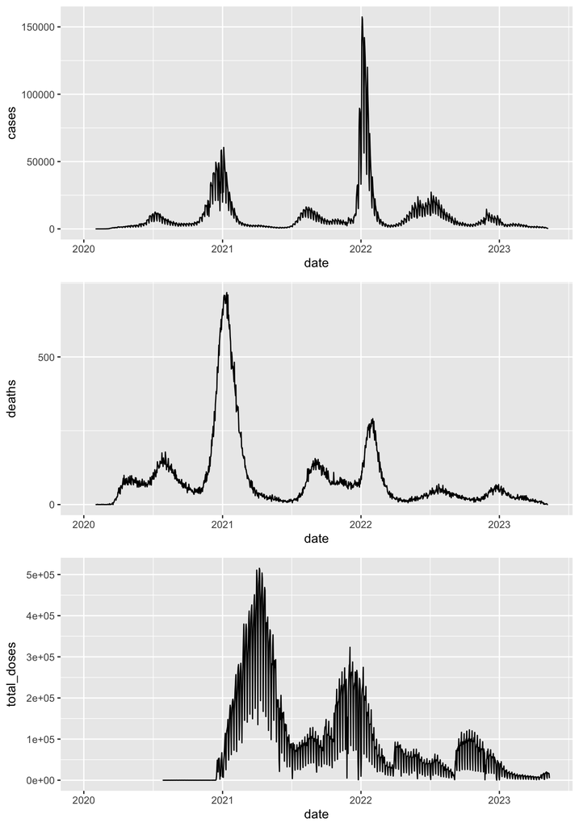

```r
library(grid)
title <- textGrob("Title",gp=gpar(fontsize=50))
grid.newpage()
grid.draw(rbind(ggplotGrob(p_case), ggplotGrob(p_death), ggplotGrob(p_vac), size = "first"))
```

Figure 3. shows a clearer picture of cases, deaths, and daily doses by date. Note that there is huge daily fluctuation because there are limited testing and vaccine service on weekends.

### Part 4 Association between vaccination rate and median income

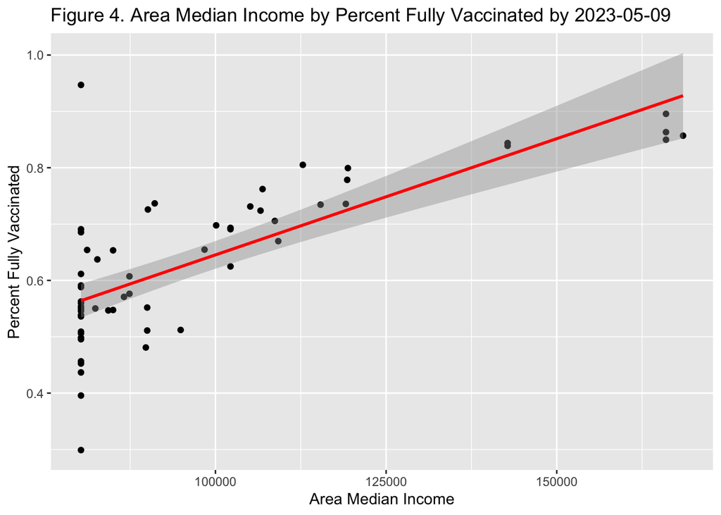

```r
covid_county1 %>%
  ggplot(mapping=aes(x = AMI, y = percent_vacc, na.rm = TRUE)) +
  geom_point() +  geom_smooth(method = "lm", color='red') +
  labs(x = "Area Median Income", y = "Percent Fully Vaccinated") +
  ggtitle("Figure 4. Area Median Income by Percent Fully Vaccinated by 2023-05-09")
```

Figure 4. shows the association between median income and percent fully vaccinated in all counties. Overall, higher median income is associated with higher vaccination rates. Notably, the influencial point at the top left corner is Imperial County.

## Conclusion

From the preliminary results, I have witnessed the difference in the impact of COVID-19 pandemic on communities in California. From Tabel 1, counties with densely populated urban centers, such as Los Angeles County, have borne the brunt of the virus’s rapid transmission. From table 2 and 3, it is evident counties with the highest vaccination rates share a similar trait – they generally the wealthiest counties in California. And not surprisingly, some counties on the bottom of the list also have the lowest incomes, and are more rural.

In contrast to densely populated urban centers, rural and less densely populated areas have faced unique challenges, possibly due to limited access to healthcare facilities and vaccine distribution. Therefore, further analysis investigates whether median income is associated with vaccination rates. Figure 4 provides evidence and shows that higher median income is associated with higher vaccination rates

In moving forward, it is imperative that the lessons learned from the differential impact of COVID-19 on California’s counties inform future public health planning. This means addressing the unique needs and vulnerabilities of each region and ensuring that healthcare resources are distributed equitably. It also necessitates continued efforts to promote vaccine access, education, and outreach to address disparities in vaccination rates.